# Self-reported expressibility predicts communicative success: Open dataset, validation, and simulation

# 7 Descriptive statistics

## 7.1 Participants

How many participants?

```r
length(unique(data$exp_ID))
```

```
## [1] 215
```

```r
# 215
```

Let’s also learn something about the participants.

```r
# Gender distribution
data %>%
  distinct(exp_ID, gender) %>% # show a list of gender of each participant
  count(gender) %>% # make a cumulative count
  arrange(desc(n)) # arrange in descending order
```

| gender | n |
| --- | --- |
| 1 | 173 |
| 2 | 41 |
| 3 | 1 |

```r
#"1" = "female", "2" = "male", "3" = "diverse", "4" = NA_character

# Age distribution
data %>% summarize(
  min_age = min(age),
  max_age = max(age),
  mean_age = mean(age),
  median_age = median(age)
)
```

| min_age | max_age | mean_age | median_age |
| --- | --- | --- | --- |
| 18 | 68 | 20.28135 | 19 |

```r
# Education distribution
data %>%
  distinct(exp_ID, education) %>%
  count(education) %>%
  arrange(desc(n))
```

| education | n |
| --- | --- |
| 6 | 111 |
| 2 | 66 |
| 3 | 29 |
| 7 | 6 |
| 4 | 2 |
| 5 | 1 |

```r
# Current location
data %>%
  distinct(exp_ID, currentloc) %>%
  count(currentloc) %>%
  arrange(desc(n))
```

| currentloc | n |
| --- | --- |
| 1 | 160 |
| 5 | 39 |
| 2 | 8 |
| 4 | 7 |
| 3 | 1 |

```r
# Country
data %>%
  distinct(exp_ID, country) %>%
  count(country) %>%
  arrange(desc(n))
```

| country | n |
| --- | --- |
| NL | 212 |
| BE | 2 |
| DE | 1 |

```r
# Dyslexia
data %>%
  distinct(exp_ID, dyslexia) %>%
  count(dyslexia) %>%
  arrange(desc(n))
```

| dyslexia | n |
| --- | --- |
| 2 | 208 |
| 1 | 7 |

```r
# Mobility
data %>%
  distinct(exp_ID, mobility) %>%
  count(mobility) %>%
  arrange(desc(n))
```

| mobility | n |
| --- | --- |
| 2 | 212 |
| 1 | 3 |

```r
# Second L1
data %>%
  distinct(exp_ID, natlang2) %>%
  count(natlang2) %>%
  arrange(desc(n))
```

| natlang2 | n |
| --- | --- |
| NA | 211 |
| chinees | 1 |
| engels | 1 |
| farsi | 1 |
| frans | 1 |

```r
# Third L1
data %>%
  distinct(exp_ID, natlang3) %>%
  count(natlang3) %>%
  arrange(desc(n))
```

| natlang3 | n |
| --- | --- |
| NA | 213 |
| duits | 1 |
| engels | 1 |

```r
# L2
data %>%
  distinct(exp_ID, lang1) %>%
  count(lang1) %>%
  arrange(desc(n))
```

| lang1 | n |
| --- | --- |
| engels | 201 |
| duits | 5 |
| NA | 3 |
| frans | 1 |
| hindoestaans | 1 |
| marokkaans | 1 |
| nederlands | 1 |
| servo-kroatisch | 1 |
| syrisch | 1 |

```r
# L3
data %>%
  distinct(exp_ID, lang2) %>%
  count(lang2) %>%
  arrange(desc(n))
```

| lang2 | n |
| --- | --- |
| NA | 124 |
| duits | 64 |
| frans | 15 |
| engels | 6 |
| spaans | 5 |
| koreaans | 1 |

```r
# L4
data %>%
  distinct(exp_ID, lang3) %>%
  count(lang3) %>%
  arrange(desc(n))
```

| lang3 | n |
| --- | --- |
| NA | 182 |
| frans | 15 |
| duits | 10 |
| spaans | 5 |
| engels | 1 |
| italiaans | 1 |
| zweeds | 1 |

```r
# Sensory preference
data %>%
  distinct(exp_ID, sensorypref) %>%
  count(sensorypref) %>%
  arrange(desc(n))
```

| sensorypref | n |
| --- | --- |
| 5 | 96 |
| 2 | 59 |
| 14 | 22 |
| 1 | 19 |
| 11 | 10 |
| 6 | 2 |
| 9 | 2 |
| 3 | 1 |
| 4 | 1 |
| 8 | 1 |

[output cut: 2 more lines]

```r
# 1 - hearing only
# 11 - hearing + visual + taste
# 14 - all: hearing + visual + taste + other
# 2 - visual only
# 3 - taste only
# 4 - other
# 5 - hearing + visual
# 6 - hearing + taste
# 7 - hearing + other
# 8 - visual + taste
# 9 - visual + other
```

How much time did each participant take?

```r
library(lubridate)

# Total duration in minutes
data %>% summarize(
    min_duration = seconds_to_period(min(duration, na.rm = TRUE)),
    max_duration = seconds_to_period(max(duration, na.rm = TRUE)),
    mean_duration = seconds_to_period(mean(duration, na.rm = TRUE)),
    median_duration = seconds_to_period(median(duration, na.rm = TRUE))
  )
```

| min_duration | max_duration | mean_duration | median_duration |
| --- | --- | --- | --- |
| 2M 11.171699999928S | 40M 41.8693000001899S | 7M 22.2320391070645S | 6M 23.3729S |

```r
# Single concept response time in seconds
data %>% summarize(
    min_response_time = min(response_time, na.rm = TRUE),
    max_response_time = max(response_time, na.rm = TRUE),
    mean_response_time = mean(response_time, na.rm = TRUE)
  )
```

| min_response_time | max_response_time | mean_response_time |
| --- | --- | --- |
| 0.5511 | 23.0272 | 4.713395 |

## 7.2 Words

How many words?

```r
length(unique(data$word))
```

```
## [1] 206
```

And let’s look at the words more closely.

```r
# PoS distribution
data %>%
  distinct(word, PoS) %>%
  count(PoS) %>%
  arrange(desc(n))
```

| PoS | n |
| --- | --- |
| noun | 79 |
| adjective | 58 |
| verb | 49 |
| adverb | 9 |
| pronoun | 8 |
| question | 2 |
| determiner | 1 |

```r
# Semantic category distribution
data %>%
  distinct(word, SemanticCat) %>%
  count(SemanticCat) %>%
  arrange(desc(n))
```

| SemanticCat | n |
| --- | --- |
| sensory | 44 |
| action | 36 |
| body | 24 |
| environment | 13 |
| thing | 12 |
| animal | 9 |
| social | 9 |
| abstract | 8 |
| qualtities | 8 |
| size | 8 |

[output cut: 9 more lines]

```r
# Semantic subcategory distribution
data %>%
  distinct(word, SemanticSubcat) %>%
  count(SemanticSubcat) %>%
  arrange(desc(n))
```

| SemanticSubcat | n |
| --- | --- |
| other | 21 |
| environment | 13 |
| object | 12 |
| manual | 11 |
| gustatory | 10 |
| locomotion | 10 |
| visual | 10 |
| animal | 9 |
| haptic | 9 |
| social | 9 |

[output cut: 17 more lines]

```r
# Later also analyses on the different ratings
```

## 7.3 Modality / Expressibility

Let’s look at the ratings from the perspective of modality.

```r
# How many times each word was rated in each modality
word_modality_counts <- data %>%
  count(word, modality) %>%
  arrange(desc(n))
word_modality_counts
```

| word | modality | n |
| --- | --- | --- |
| geurig | vocal | 23 |
| goed | vocal | 23 |
| kat | vocal | 23 |
| klein | multimodal | 23 |
| nacht | multimodal | 23 |
| slapen | multimodal | 23 |
| sommige | vocal | 23 |
| wat | multimodal | 23 |
| zwaar | vocal | 23 |
| ademen | gesture | 22 |

[output cut: 608 more lines]

```r
# Which words have the fewest ratings per modality
word_modality_counts %>% filter(n == min(n))
```

| word | modality | n |
| --- | --- | --- |
| hoorn | multimodal | 16 |
| rook | vocal | 16 |

```r
# 16 ratings is the minimum
```

And now at raw expressibility.

```r
# Calculate average raw expressibility per word per modality.
expressibility_avg <- data %>%
  group_by(word, modality) %>%
  summarize(avg_expressibility = mean(expressibility, na.rm = TRUE), .groups = "drop") %>%
  arrange(desc(avg_expressibility))
expressibility_avg
```

| word | modality | avg_expressibility |
| --- | --- | --- |
| lachen | vocal | 0.817062665 |
| koud | gesture | 0.816323331 |
| lopen | multimodal | 0.810321958 |
| één | gesture | 0.804115428 |
| slapen | gesture | 0.801770847 |
| springen | gesture | 0.781619575 |
| hond | vocal | 0.780591674 |
| vliegen | gesture | 0.779137027 |
| jeuk | gesture | 0.777496156 |
| slapen | multimodal | 0.776675083 |

[output cut: 608 more lines]

```r
# Create datasets for each modality (sorted and with ranking)
gesture_avg <- expressibility_avg %>%
  filter(modality == "gesture") %>%
  arrange(desc(avg_expressibility)) %>%
  mutate(n = row_number())
gesture_avg
```

| word | modality | avg_expressibility | n |
| --- | --- | --- | --- |
| koud | gesture | 0.816323331 | 1 |
| één | gesture | 0.804115428 | 2 |
| slapen | gesture | 0.801770847 | 3 |
| springen | gesture | 0.781619575 | 4 |
| vliegen | gesture | 0.779137027 | 5 |
| jeuk | gesture | 0.777496156 | 6 |
| gooien | gesture | 0.765222747 | 7 |
| vechten | gesture | 0.741034189 | 8 |
| drinken | gesture | 0.739941719 | 9 |
| blij | gesture | 0.737544023 | 10 |

[output cut: 196 more lines]

```r
multimodal_avg <- expressibility_avg %>%
  filter(modality == "multimodal") %>%
  arrange(desc(avg_expressibility)) %>%
  mutate(n = row_number())
multimodal_avg
```

| word | modality | avg_expressibility | n |
| --- | --- | --- | --- |
| lopen | multimodal | 0.810321958 | 1 |
| slapen | multimodal | 0.776675083 | 2 |
| lachen | multimodal | 0.772921880 | 3 |
| sterk | multimodal | 0.766986458 | 4 |
| rennen | multimodal | 0.765543495 | 5 |
| kotsen | multimodal | 0.765139300 | 6 |
| verdrietig | multimodal | 0.758175246 | 7 |
| jeuk | multimodal | 0.756390508 | 8 |
| één | multimodal | 0.744349479 | 9 |
| blazen | multimodal | 0.736944026 | 10 |

[output cut: 196 more lines]

```r
vocal_avg <- expressibility_avg %>%
  filter(modality == "vocal") %>%
  arrange(desc(avg_expressibility)) %>%
  mutate(n = row_number())
vocal_avg
```

| word | modality | avg_expressibility | n |
| --- | --- | --- | --- |
| lachen | vocal | 0.817062665 | 1 |
| hond | vocal | 0.780591674 | 2 |
| kat | vocal | 0.774177507 | 3 |
| huilen | vocal | 0.703667627 | 4 |
| blazen | vocal | 0.689395990 | 5 |
| kotsen | vocal | 0.670259717 | 6 |
| ademen | vocal | 0.637362104 | 7 |
| grommen | vocal | 0.619774563 | 8 |
| piepen | vocal | 0.609672607 | 9 |
| slang | vocal | 0.581116496 | 10 |

[output cut: 196 more lines]

```r
# Add the ranking information to expressibility_avg
expressibility_avg <- merge(expressibility_avg, gesture_avg[, c("word", "modality", "n")], by = c("word", "modality"), all.x = TRUE)
expressibility_avg <- merge(expressibility_avg, vocal_avg[, c("word", "modality", "n")], by = c("word", "modality"), all.x = TRUE)
expressibility_avg <- merge(expressibility_avg, multimodal_avg[, c("word", "modality", "n")], by = c("word", "modality"), all.x = TRUE)
expressibility_avg$n <- coalesce(expressibility_avg$n.x, expressibility_avg$n.y, expressibility_avg$n)
expressibility_avg <- expressibility_avg %>%
  select(-c(n.x, n.y))

# Estimate the divergence in ratings by expressibility
expressibility_avg <- expressibility_avg %>%
  group_by(word) %>%
  mutate(diff_expr = max(avg_expressibility) - min(avg_expressibility)) %>%
  ungroup()

# Estimate the divergence in ratings by ranking
expressibility_avg <- expressibility_avg %>%
  group_by(word) %>%
  mutate(diff_rank = max(n) - min(n)) %>%
  ungroup()
```

Let’s print the list to see the divergence.

```r
# expressibility average by difference in expressibility
expressibility_avg %>%
  arrange(desc(diff_expr))
```

| word | modality | avg_expressibility | n | diff_expr | diff_rank |
| --- | --- | --- | --- | --- | --- |
| één | gesture | 0.804115428 | 2 | 1.39214643 | 129 |
| één | multimodal | 0.744349479 | 9 | 1.39214643 | 129 |
| één | vocal | -0.588031006 | 131 | 1.39214643 | 129 |
| rond | gesture | 0.646974316 | 25 | 1.28900165 | 119 |
| rond | multimodal | 0.693489089 | 15 | 1.28900165 | 119 |
| rond | vocal | -0.595512560 | 134 | 1.28900165 | 119 |
| kruipen | gesture | 0.700779685 | 18 | 1.27244745 | 107 |
| kruipen | multimodal | 0.611766467 | 35 | 1.27244745 | 107 |
| kruipen | vocal | -0.571667767 | 125 | 1.27244745 | 107 |
| zien | gesture | 0.564490907 | 35 | 1.26486747 | 146 |

[output cut: 608 more lines]

```r
# expressibility average by difference in rank
expressibility_avg %>%
  arrange(desc(diff_rank))
```

| word | modality | avg_expressibility | n | diff_expr | diff_rank |
| --- | --- | --- | --- | --- | --- |
| piepen | gesture | -0.635832888 | 200 | 1.24550550 | 191 |
| piepen | multimodal | 0.275590167 | 81 | 1.24550550 | 191 |
| piepen | vocal | 0.609672607 | 9 | 1.24550550 | 191 |
| zoemen | gesture | -0.552725740 | 188 | 1.14133811 | 177 |
| zoemen | multimodal | 0.588612366 | 42 | 1.14133811 | 177 |
| zoemen | vocal | 0.556588416 | 11 | 1.14133811 | 177 |
| zien | gesture | 0.564490907 | 35 | 1.26486747 | 146 |
| zien | multimodal | 0.507809357 | 49 | 1.26486747 | 146 |
| zien | vocal | -0.700376559 | 181 | 1.26486747 | 146 |
| onweer | gesture | -0.409674215 | 173 | 0.61478487 | 138 |

[output cut: 608 more lines]

# 8 Visual

We have ratings between -1 and 1. For better handling during modelling, we will normalized to create values between 0 and 1

```r
# creates values between 0 and 1
data$expressibility_norm <- (data$expressibility-min(data$expressibility))/(max(data$expressibility)-min(data$expressibility))
```

Count raw mean for word per modality

```r
# Calculate average raw expressibility per word per modality.
expressibility_norm_avg <- data %>%
  group_by(word, modality) %>%
  summarize(avg_expressibility_norm = mean(expressibility_norm, na.rm = TRUE), .groups = "drop") %>%
  arrange(desc(avg_expressibility_norm))
expressibility_norm_avg
```

| word | modality | avg_expressibility_norm |
| --- | --- | --- |
| lachen | vocal | 0.90853133 |
| koud | gesture | 0.90816167 |
| lopen | multimodal | 0.90516098 |
| één | gesture | 0.90205771 |
| slapen | gesture | 0.90088542 |
| springen | gesture | 0.89080979 |
| hond | vocal | 0.89029584 |
| vliegen | gesture | 0.88956851 |
| jeuk | gesture | 0.88874808 |
| slapen | multimodal | 0.88833754 |

[output cut: 608 more lines]

```r
# Create datasets for each modality (sorted and with ranking)
gesture_norm_avg <- expressibility_norm_avg %>%
  filter(modality == "gesture") %>%
  arrange(desc(avg_expressibility_norm)) %>%
  mutate(n = row_number())
gesture_norm_avg
```

| word | modality | avg_expressibility_norm | n |
| --- | --- | --- | --- |
| koud | gesture | 0.9081617 | 1 |
| één | gesture | 0.9020577 | 2 |
| slapen | gesture | 0.9008854 | 3 |
| springen | gesture | 0.8908098 | 4 |
| vliegen | gesture | 0.8895685 | 5 |
| jeuk | gesture | 0.8887481 | 6 |
| gooien | gesture | 0.8826114 | 7 |
| vechten | gesture | 0.8705171 | 8 |
| drinken | gesture | 0.8699709 | 9 |
| blij | gesture | 0.8687720 | 10 |

[output cut: 196 more lines]

```r
multimodal_norm_avg <- expressibility_norm_avg %>%
  filter(modality == "multimodal") %>%
  arrange(desc(avg_expressibility_norm)) %>%
  mutate(n = row_number())
multimodal_norm_avg
```

| word | modality | avg_expressibility_norm | n |
| --- | --- | --- | --- |
| lopen | multimodal | 0.9051610 | 1 |
| slapen | multimodal | 0.8883375 | 2 |
| lachen | multimodal | 0.8864609 | 3 |
| sterk | multimodal | 0.8834932 | 4 |
| rennen | multimodal | 0.8827717 | 5 |
| kotsen | multimodal | 0.8825696 | 6 |
| verdrietig | multimodal | 0.8790876 | 7 |
| jeuk | multimodal | 0.8781953 | 8 |
| één | multimodal | 0.8721747 | 9 |
| blazen | multimodal | 0.8684720 | 10 |

[output cut: 196 more lines]

```r
vocal_norm_avg <- expressibility_norm_avg %>%
  filter(modality == "vocal") %>%
  arrange(desc(avg_expressibility_norm)) %>%
  mutate(n = row_number())
vocal_norm_avg
```

| word | modality | avg_expressibility_norm | n |
| --- | --- | --- | --- |
| lachen | vocal | 0.90853133 | 1 |
| hond | vocal | 0.89029584 | 2 |
| kat | vocal | 0.88708875 | 3 |
| huilen | vocal | 0.85183381 | 4 |
| blazen | vocal | 0.84469799 | 5 |
| kotsen | vocal | 0.83512986 | 6 |
| ademen | vocal | 0.81868105 | 7 |
| grommen | vocal | 0.80988728 | 8 |
| piepen | vocal | 0.80483630 | 9 |
| slang | vocal | 0.79055825 | 10 |

[output cut: 196 more lines]

```r
# Add the ranking information to expressibility_avg
expressibility_norm_avg <- merge(expressibility_norm_avg, gesture_norm_avg[, c("word", "modality", "n")], by = c("word", "modality"), all.x = TRUE)
expressibility_norm_avg <- merge(expressibility_norm_avg, multimodal_norm_avg[, c("word", "modality", "n")], by = c("word", "modality"), all.x = TRUE)
expressibility_norm_avg <- merge(expressibility_norm_avg, vocal_norm_avg[, c("word", "modality", "n")], by = c("word", "modality"), all.x = TRUE)
expressibility_norm_avg$n <- coalesce(expressibility_norm_avg$n.x, expressibility_norm_avg$n.y, expressibility_norm_avg$n)
expressibility_norm_avg <- expressibility_norm_avg %>%
  select(-c(n.x, n.y))

# Estimate the divergence in ratings by expressibility
expressibility_norm_avg <- expressibility_norm_avg %>%
  group_by(word) %>%
  mutate(diff_expr = max(avg_expressibility_norm) - min(avg_expressibility_norm)) %>%
  ungroup()

# Estimate the divergence in ratings by ranking
expressibility_norm_avg <- expressibility_norm_avg %>%
  group_by(word) %>%
  mutate(diff_rank = max(n) - min(n)) %>%
  ungroup()


# save this df
write.csv(expressibility_norm_avg, paste0(datasets, "df_express_dutch_norm_avg.csv"))
```

Some plots.

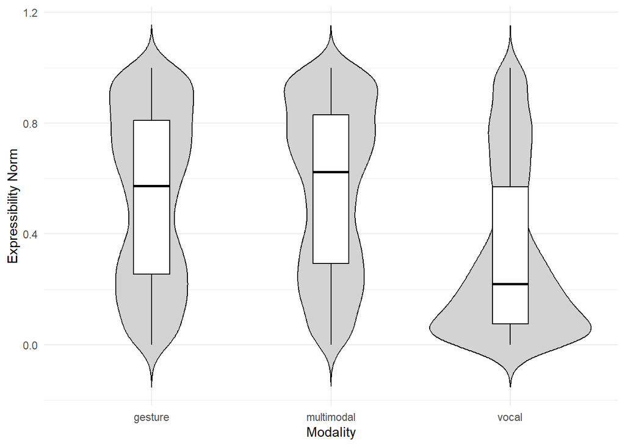

```r
# Create a violin plot with box plot overlay
ggplot(data, aes(x = modality, y = expressibility_norm)) +
  geom_violin(fill = "lightgray", color = "black", trim = FALSE) +
  geom_boxplot(width = 0.2, fill = "white", color = "black", outlier.shape = NA) +
  labs(x = "Modality", y = "Expressibility Norm") +
  theme_minimal()
```

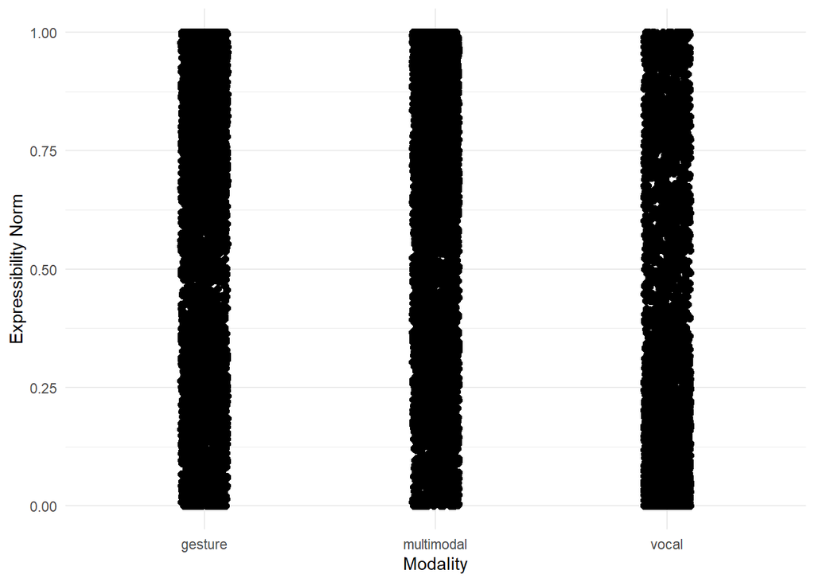

```r
# Create a scatter plot with a loess smoother
ggplot(data, aes(x = modality, y = expressibility_norm)) +
  geom_point(position = position_jitter(width = 0.1), size = 2) +
  geom_smooth(method = "loess", se = FALSE) +
  labs(x = "Modality", y = "Expressibility Norm") +
  theme_minimal()
```

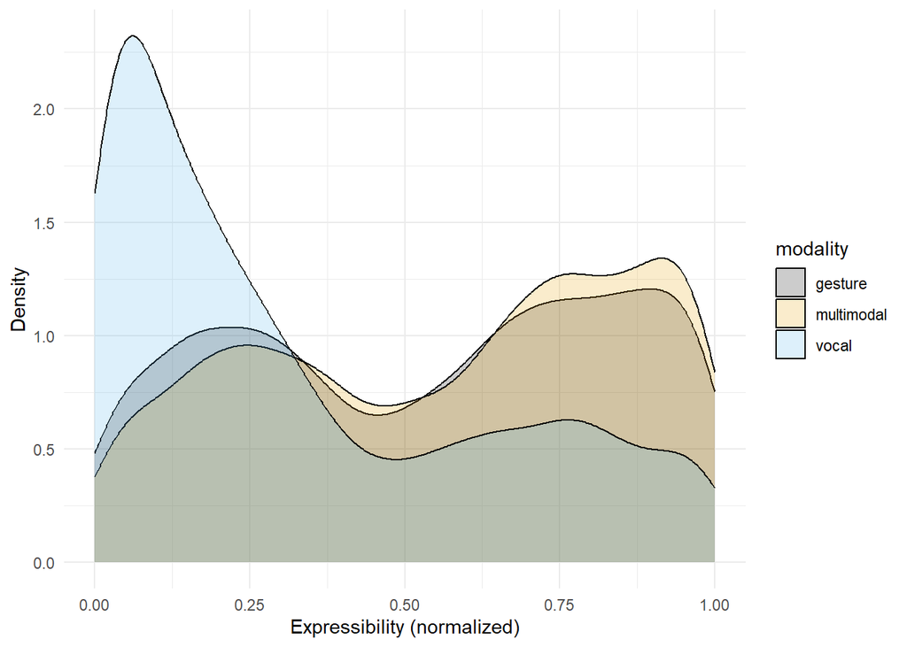

```r
ggplot(data, aes(x = expressibility_norm, fill = modality)) +
  geom_density(alpha = 0.2) +
  scale_fill_manual(values = colorBlindBlack8) +
  labs(x = "Expressibility (normalized)", y = "Density") +
  theme_minimal()
```

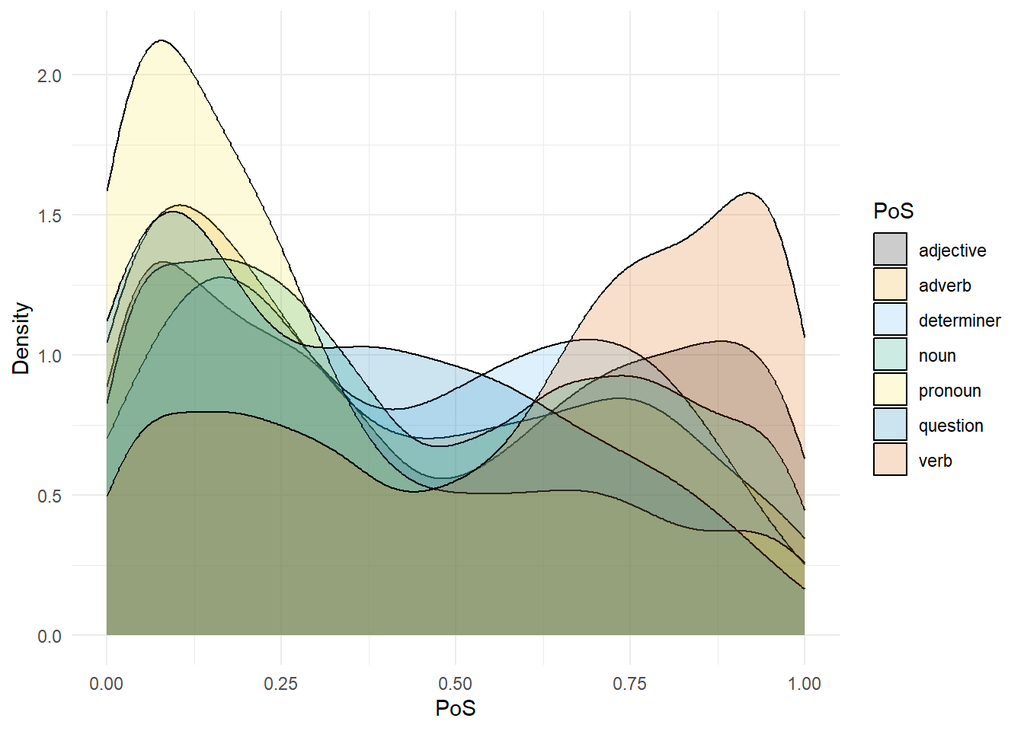

```r
ggplot(data, aes(x = expressibility_norm, fill = PoS)) +
  geom_density(alpha = 0.2) +
  scale_fill_manual(values = colorBlindBlack8) +
  labs(x = "PoS", y = "Density") +
  theme_minimal()
```

# 9 Modeling

## 9.1 Contrast / dummy coding

```r
# Gender
data$gender <- as.factor(data$gender)
contrasts(data$gender)
```

```
##   2 3
## 1 0 0
## 2 1 0
## 3 0 1
```

```r
# Modality
data$modality <- as.factor(data$modality)
contrasts(data$modality)
```

```
##            multimodal vocal
## gesture             0     0
## multimodal          1     0
## vocal               0     1
```

```r
# Word
data$word <- as.character(data$word)
data$word <- as.factor(data$word)
```

## 9.2 Levels

We change the levels() to reflect our beliefs.

```r
library(forcats)

levels(data$modality)
```

```
## [1] "gesture"    "multimodal" "vocal"
```

```r
# make multimodality the baseline
levels(data$PoS)
```

```
## [1] "adjective"  "adverb"     "determiner" "noun"       "pronoun"
## [6] "question"   "verb"
```

```r
# make verb the baseline
levels(data$posneg)
```

```r
# negative is baseline

data <- data %>%
  mutate(modality = fct_relevel(modality, "multimodal"),
         PoS = fct_relevel(PoS, "verb"))
```

## 9.3 Define priors

```r
library(brms)

get_prior(formula = expressibility ~ 1 + modality +
                                  (1 + modality || word),
          data = data,
          family = zero_inflated_beta())
```

| prior | class | coef | group | resp | dpar | nlpar | lb | ub | source |
| --- | --- | --- | --- | --- | --- | --- | --- | --- | --- |
|  | b |  |  |  |  |  |  |  | default |
|  | b | modalitygesture |  |  |  |  |  |  | default |
|  | b | modalityvocal |  |  |  |  |  |  | default |
| student_t(3, 0, 2.5) | Intercept |  |  |  |  |  |  |  | default |
| gamma(0.01, 0.01) | phi |  |  |  |  |  | 0 |  | default |
| student_t(3, 0, 2.5) | sd |  |  |  |  |  | 0 |  | default |
|  | sd |  | word |  |  |  |  |  | default |
|  | sd | Intercept | word |  |  |  |  |  | default |
|  | sd | modalitygesture | word |  |  |  |  |  | default |
|  | sd | modalityvocal | word |  |  |  |  |  | default |

[output cut: 1 more lines]

```r
# Define the priors
priors_beta <- c(
  prior('normal(0, 1)', class = 'Intercept', lb = 0, ub = 1),
  prior('normal(0, 0.5)', class = 'b')  # Priors for other predictors
)

priors_beta_narrow <- c(
  prior('normal(0.5, 0.5)', class = 'Intercept', lb = 0, ub = 1),
  prior('normal(0, 0.2)', class = 'b')
  )
```

## 9.4 Zero-inflated beta model

I run a few models first with various priors and predictors.

```r
# https://journal.r-project.org/archive/2015/RJ-2015-019/
# https://www.andrewheiss.com/blog/2021/11/08/beta-regression-guide/#special-case-1-zero-one-inflated-beta-regression
# https://mvuorre.github.io/posts/2019-02-18-analyze-analog-scale-ratings-with-zero-one-inflated-beta-models/#zoib-regression

# compute mdl
mdl_zoib <- brm(bf(expressibility_norm ~ 1 + modality + (1 + modality || word),
                   phi ~ modality + (1 + modality || word),
                   zoi ~ modality + (1 + modality || word),
                   coi ~ modality + (1 + modality || word)),
                data = data,
                prior = priors_beta,
                family = zero_one_inflated_beta(),
                backend = "cmdstanr",
                cores = 4,
                chains = 4,
                init = 0,
                iter = 4000,
                warmup = 2000,
                seed = 42,
                control = list(max_treedepth = 13,
                               adapt_delta = 0.99),
                file = paste0(models, "mdl_zoib.rds"))

# compress the model more
saveRDS(mdl_zoib, file = paste0(models, "mdl_zoib.rds"), compress = "xz")
```

Let’s check how it looks like.

```r
mdl_zoib <- readRDS(paste0(models, "mdl_zoib.rds"))

summary(mdl_zoib)
```

```
##  Family: zero_one_inflated_beta
##   Links: mu = logit; phi = log; zoi = logit; coi = logit
## Formula: expressibility_norm ~ 1 + modality + (1 + modality || word)
##          phi ~ modality + (1 + modality || word)
##          zoi ~ modality + (1 + modality || word)
##          coi ~ modality + (1 + modality || word)
##    Data: data (Number of observations: 12678)
##   Draws: 4 chains, each with iter = 4000; warmup = 2000; thin = 1;
##          total post-warmup draws = 8000
##
## Multilevel Hyperparameters:
## ~word (Number of levels: 206)
##                         Estimate Est.Error l-95% CI u-95% CI Rhat Bulk_ESS
## sd(Intercept)               0.83      0.04     0.75     0.93 1.00      942
## sd(modalitygesture)         0.28      0.03     0.21     0.34 1.00     1703
## sd(modalityvocal)           0.72      0.04     0.64     0.81 1.00     2241
## sd(phi_Intercept)           0.24      0.02     0.20     0.28 1.00     2278
## sd(phi_modalitygesture)     0.22      0.04     0.13     0.30 1.00     1587
## sd(phi_modalityvocal)       0.38      0.04     0.31     0.46 1.00     2354
## sd(zoi_Intercept)           0.24      0.14     0.01     0.53 1.00     1262
## sd(zoi_modalitygesture)     0.66      0.26     0.09     1.15 1.00     1166
## sd(zoi_modalityvocal)       0.28      0.19     0.01     0.70 1.00     1831
## sd(coi_Intercept)           4.04      1.28     2.13     7.06 1.00     1939
## sd(coi_modalitygesture)     1.98      1.59     0.08     5.87 1.00      953
## sd(coi_modalityvocal)       1.91      1.56     0.07     5.84 1.00     1015
##                         Tail_ESS
## sd(Intercept)               2203
## sd(modalitygesture)         3563
## sd(modalityvocal)           4016
## sd(phi_Intercept)           4274
## sd(phi_modalitygesture)     1675
## sd(phi_modalityvocal)       4581
## sd(zoi_Intercept)           2571
## sd(zoi_modalitygesture)     1257
## sd(zoi_modalityvocal)       3012
## sd(coi_Intercept)           3410
## sd(coi_modalitygesture)     2710
## sd(coi_modalityvocal)       1969
##
## Regression Coefficients:
##                     Estimate Est.Error l-95% CI u-95% CI Rhat Bulk_ESS Tail_ESS
## Intercept               0.39      0.03     0.34     0.45 1.00     1484     2382
## phi_Intercept           1.25      0.03     1.20     1.31 1.00     5811     6530
## zoi_Intercept          -4.08      0.13    -4.33    -3.85 1.00     8409     6008
## coi_Intercept           1.84      0.75     0.53     3.48 1.00     4038     4550
## modalitygesture        -0.11      0.03    -0.17    -0.05 1.00     6046     6459
## modalityvocal          -0.98      0.05    -1.08    -0.88 1.00     1395     2677
## phi_modalitygesture     0.02      0.03    -0.05     0.08 1.00     5563     6066
## phi_modalityvocal      -0.03      0.04    -0.11     0.05 1.00     4598     5033
## zoi_modalitygesture    -0.10      0.23    -0.58     0.33 1.00     2644     4699
## zoi_modalityvocal       0.05      0.18    -0.31     0.39 1.00     7664     6356
## coi_modalitygesture    -0.45      0.91    -2.24     1.45 1.00     5890     5481
## coi_modalityvocal      -5.03      1.51    -8.64    -2.71 1.00     2411     2724
##
## Draws were sampled using sample(hmc). For each parameter, Bulk_ESS
## and Tail_ESS are effective sample size measures, and Rhat is the potential
## scale reduction factor on split chains (at convergence, Rhat = 1).
```

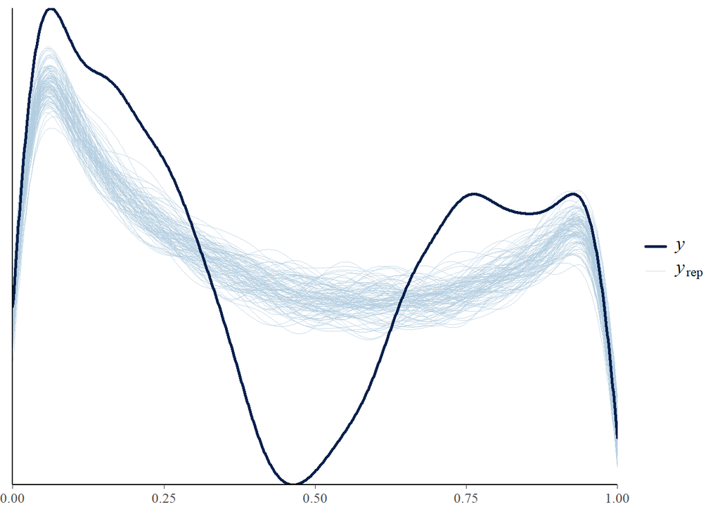

```r
pp_check(mdl_zoib, ndraws = 100)
```

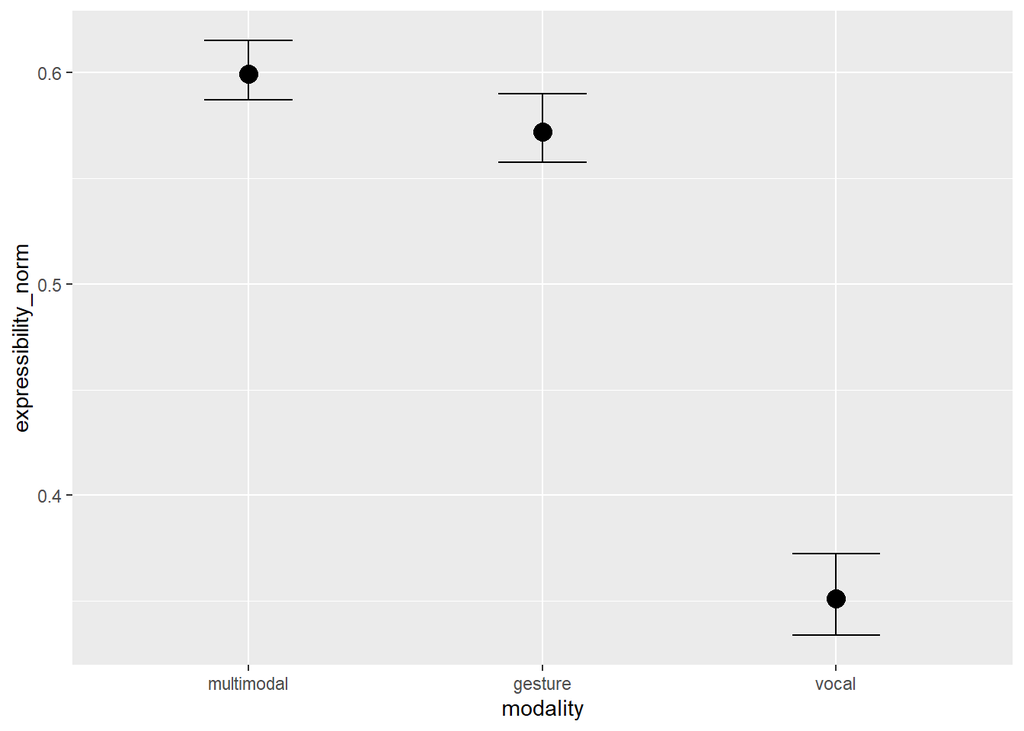

```r
conditional_effects(mdl_zoib, sample_prior = "only")
```

Let’s compute the loo for model comparison.

```r
# run loo mdl
if (file.exists(paste0(models, "mdl_zoib_loo.rds"))) {
  mdl_zoib_loo <- readRDS(paste0(models, "mdl_zoib_loo.rds"))
} else {
  mdl_zoib_loo <- loo(mdl_zoib)
  saveRDS(mdl_zoib_loo, paste0(models, "mdl_zoib_loo.rds"))
}
```

Let’s try narrower priors.

```r
# compute mdl2
mdl_zoib2 <- brm(bf(expressibility_norm ~ 1 + modality + (1 + modality || word),
                   phi ~ modality + (1 + modality || word),
                   zoi ~ modality + (1 + modality || word),
                   coi ~ modality + (1 + modality || word)),
                data = data,
                prior = priors_beta_narrow,
                family = zero_one_inflated_beta(),
                backend = "cmdstanr",
                cores = 4,
                chains = 4,
                init = 0,
                iter = 4000,
                warmup = 2000,
                seed = 42,
                control = list(max_treedepth = 13,
                               adapt_delta = 0.99),
                file = paste0(models, "mdl_zoib2.rds"))

# compress the model more
saveRDS(mdl_zoib2, file = paste0(models, "mdl_zoib2.rds"), compress = "xz")
```

Check mdl2.

```r
mdl_zoib2 <- readRDS(paste0(models, "mdl_zoib2.rds"))

summary(mdl_zoib2)
```

```
##  Family: zero_one_inflated_beta
##   Links: mu = logit; phi = log; zoi = logit; coi = logit
## Formula: expressibility_norm ~ 1 + modality + (1 + modality || word)
##          phi ~ modality + (1 + modality || word)
##          zoi ~ modality + (1 + modality || word)
##          coi ~ modality + (1 + modality || word)
##    Data: data (Number of observations: 12678)
##   Draws: 4 chains, each with iter = 4000; warmup = 2000; thin = 1;
##          total post-warmup draws = 8000
##
## Multilevel Hyperparameters:
## ~word (Number of levels: 206)
##                         Estimate Est.Error l-95% CI u-95% CI Rhat Bulk_ESS
## sd(Intercept)               0.83      0.04     0.75     0.92 1.00     1371
## sd(modalitygesture)         0.28      0.03     0.21     0.34 1.00     2511
## sd(modalityvocal)           0.73      0.04     0.65     0.82 1.00     2717
## sd(phi_Intercept)           0.24      0.02     0.19     0.28 1.00     2917
## sd(phi_modalitygesture)     0.23      0.04     0.14     0.31 1.00     1781
## sd(phi_modalityvocal)       0.38      0.04     0.31     0.45 1.00     3172
## sd(zoi_Intercept)           0.24      0.14     0.01     0.53 1.00     1611
## sd(zoi_modalitygesture)     0.68      0.26     0.10     1.16 1.00     1345
## sd(zoi_modalityvocal)       0.27      0.19     0.01     0.71 1.00     2424
## sd(coi_Intercept)           4.03      1.24     2.14     7.00 1.00     1923
## sd(coi_modalitygesture)     2.02      1.62     0.09     6.04 1.00     1056
## sd(coi_modalityvocal)       2.05      1.66     0.07     6.27 1.00     1168
##                         Tail_ESS
## sd(Intercept)               2483
## sd(modalitygesture)         3760
## sd(modalityvocal)           4543
## sd(phi_Intercept)           4506
## sd(phi_modalitygesture)     2935
## sd(phi_modalityvocal)       5093
## sd(zoi_Intercept)           3352
## sd(zoi_modalitygesture)     1526
## sd(zoi_modalityvocal)       3743
## sd(coi_Intercept)           3814
## sd(coi_modalitygesture)     2424
## sd(coi_modalityvocal)       3080
##
## Regression Coefficients:
##                     Estimate Est.Error l-95% CI u-95% CI Rhat Bulk_ESS Tail_ESS
## Intercept               0.37      0.03     0.32     0.44 1.00     1973     3432
## phi_Intercept           1.25      0.03     1.20     1.30 1.00     8523     6993
## zoi_Intercept          -4.08      0.13    -4.34    -3.84 1.00    10634     5855
## coi_Intercept           1.87      0.75     0.56     3.56 1.00     4539     4748
## modalitygesture        -0.10      0.03    -0.16    -0.05 1.00     7998     6663
## modalityvocal          -0.92      0.05    -1.02    -0.82 1.00     2082     3168
## phi_modalitygesture     0.02      0.03    -0.05     0.08 1.00     7992     6714
## phi_modalityvocal      -0.03      0.04    -0.11     0.05 1.00     6570     6695
## zoi_modalitygesture    -0.11      0.23    -0.58     0.31 1.00     3169     5360
## zoi_modalityvocal       0.05      0.17    -0.30     0.38 1.00     9989     6174
## coi_modalitygesture    -0.44      0.91    -2.17     1.41 1.00     5513     5004
## coi_modalityvocal      -5.12      1.55    -8.80    -2.79 1.00     2628     3125
##
## Draws were sampled using sample(hmc). For each parameter, Bulk_ESS
## and Tail_ESS are effective sample size measures, and Rhat is the potential
## scale reduction factor on split chains (at convergence, Rhat = 1).
```

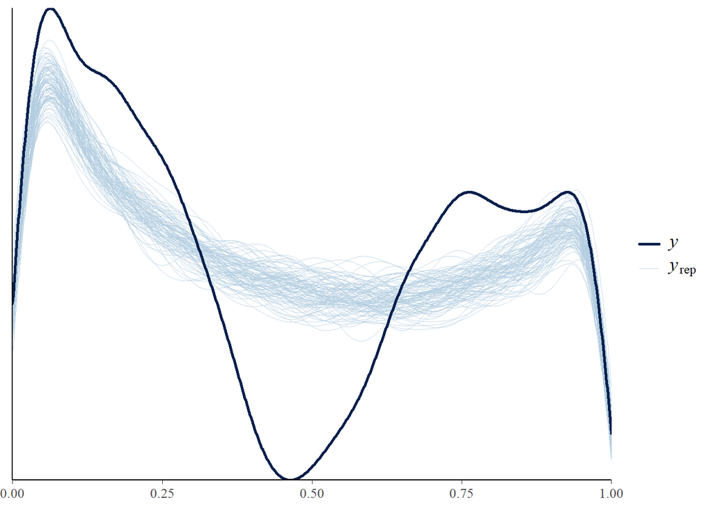

```r
pp_check(mdl_zoib2, ndraws = 100)
```

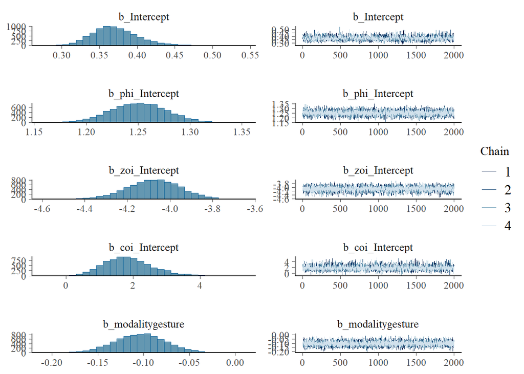

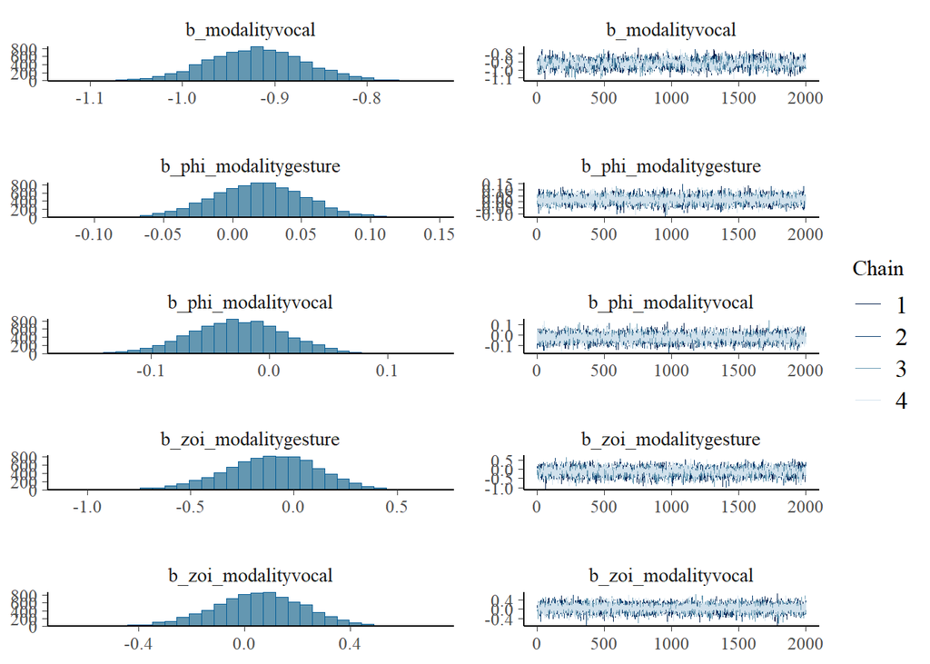

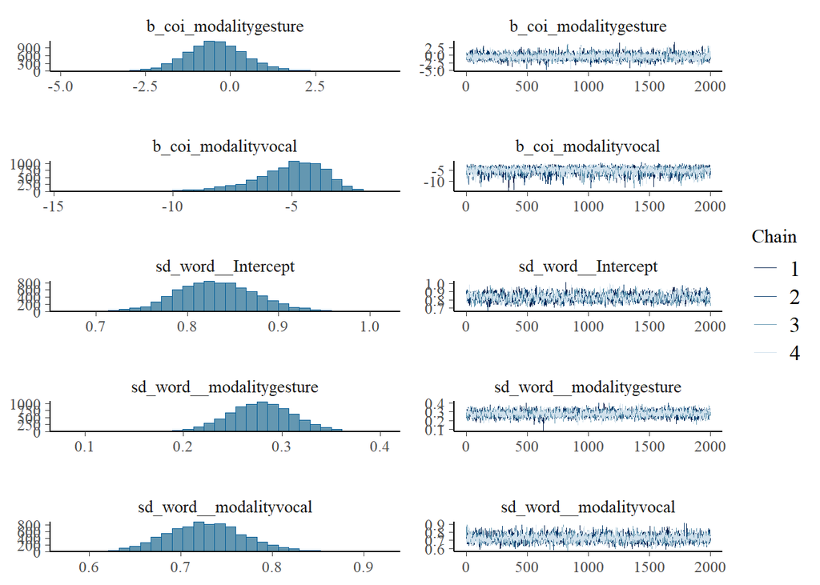

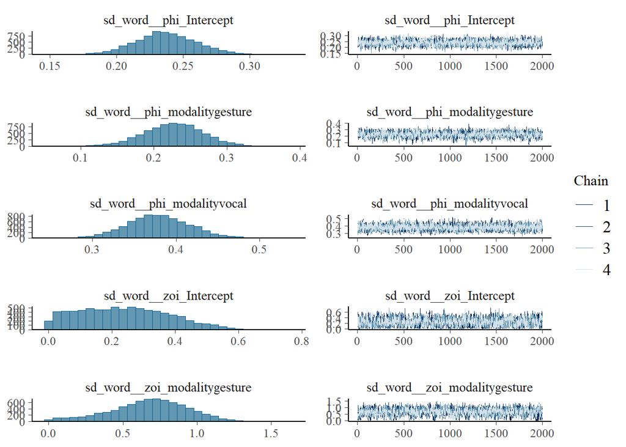

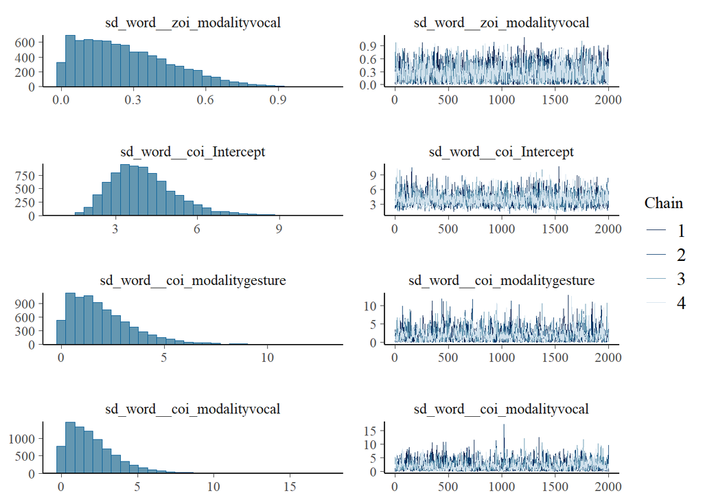

```r
plot(mdl_zoib2)
```

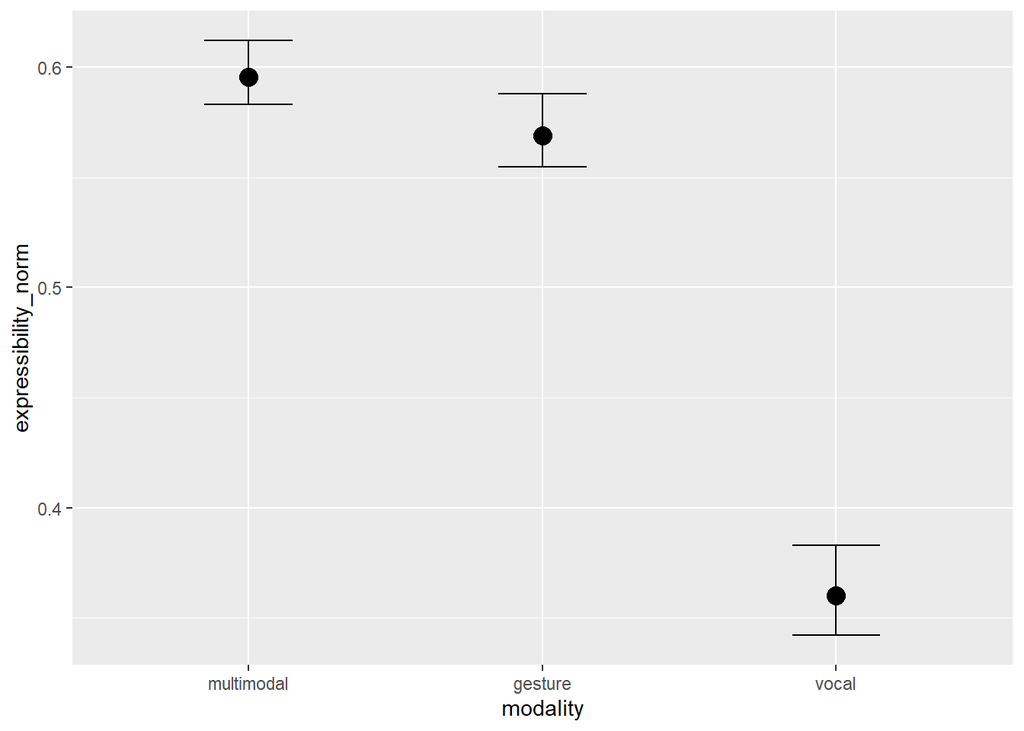

```r
conditional_effects(mdl_zoib2)
```

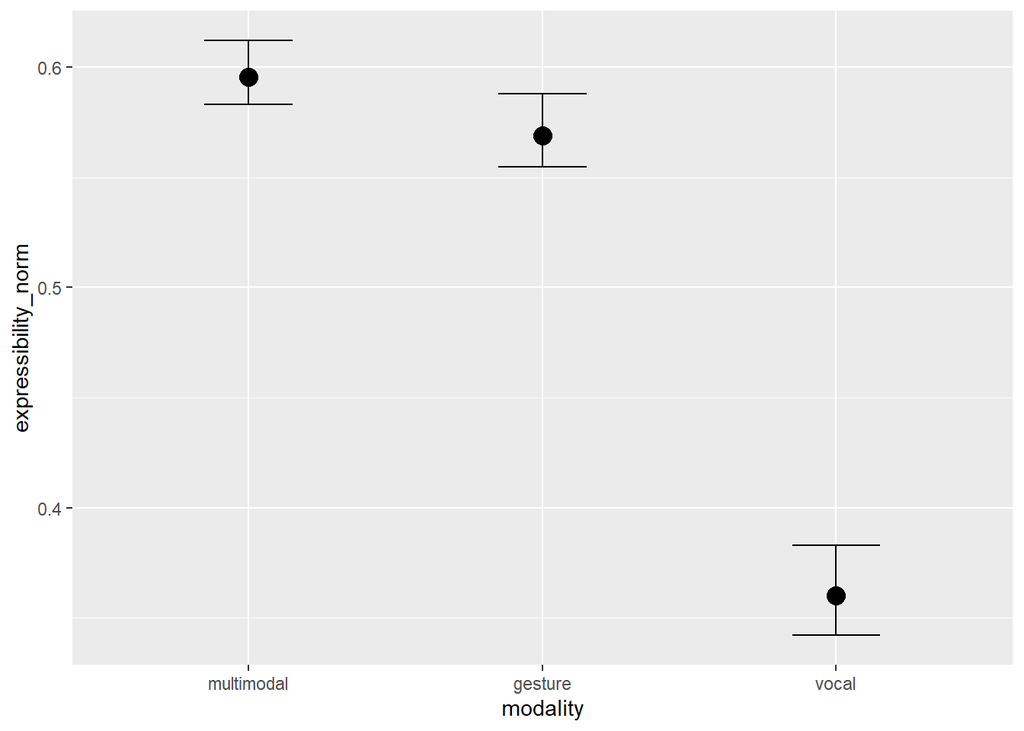

```r
conditional_effects(mdl_zoib2, sample_prior = "only")
```

Compute loo mdl2.

```r
# run loo mdl2
if (file.exists(paste0(models, "mdl_zoib2_loo.rds"))) {
  mdl_zoib2_loo <- readRDS(paste0(models, "mdl_zoib2_loo.rds"))
} else {
  mdl_zoib2_loo <- loo(mdl_zoib2)
  saveRDS(mdl_zoib2_loo, paste0(models, "mdl_zoib2_loo.rds"))
}
```

Now to model 3 with simpler structure of phi, zoi, and coi.

```r
# compute mdl3
mdl_zoib3 <- brm(bf(expressibility_norm ~ 1 + modality + (1 + modality || word),
                   phi ~ modality,
                   zoi ~ modality,
                   coi ~ modality),
                data = data,
                prior = priors_beta_narrow,
                family = zero_one_inflated_beta(),
                backend = "cmdstanr",
                cores = 4,
                chains = 4,
                init = 0,
                iter = 4000,
                warmup = 2000,
                seed = 42,
                control = list(max_treedepth = 13,
                               adapt_delta = 0.99),
                file = paste0(models, "mdl_zoib3.rds"))

# compress the model more
saveRDS(mdl_zoib3, file = paste0(models, "mdl_zoib3.rds"), compress = "xz")
```

Check mdl3.

```r
mdl_zoib3 <- readRDS(paste0(models, "mdl_zoib3.rds"))

summary(mdl_zoib3)
```

```
##  Family: zero_one_inflated_beta
##   Links: mu = logit; phi = log; zoi = logit; coi = logit
## Formula: expressibility_norm ~ 1 + modality + (1 + modality || word)
##          phi ~ modality
##          zoi ~ modality
##          coi ~ modality
##    Data: data (Number of observations: 12678)
##   Draws: 4 chains, each with iter = 4000; warmup = 2000; thin = 1;
##          total post-warmup draws = 8000
##
## Multilevel Hyperparameters:
## ~word (Number of levels: 206)
##                     Estimate Est.Error l-95% CI u-95% CI Rhat Bulk_ESS Tail_ESS
## sd(Intercept)           0.79      0.04     0.71     0.87 1.00     1809     3531
## sd(modalitygesture)     0.29      0.03     0.23     0.35 1.00     3420     5146
## sd(modalityvocal)       0.69      0.04     0.61     0.78 1.00     3575     4684
##
## Regression Coefficients:
##                     Estimate Est.Error l-95% CI u-95% CI Rhat Bulk_ESS Tail_ESS
## Intercept               0.36      0.03     0.31     0.43 1.00     2427     3912
## phi_Intercept           1.20      0.02     1.16     1.24 1.00    12609     6461
## zoi_Intercept          -4.04      0.12    -4.29    -3.82 1.00    14814     5534
## coi_Intercept           1.06      0.27     0.55     1.61 1.00    15305     6362
## modalitygesture        -0.11      0.03    -0.17    -0.05 1.00     9049     6411
## modalityvocal          -0.89      0.05    -0.99    -0.79 1.00     2750     4471
## phi_modalitygesture    -0.01      0.03    -0.07     0.04 1.00    10984     6574
## phi_modalityvocal      -0.08      0.03    -0.13    -0.02 1.00    13337     6827
## zoi_modalitygesture     0.13      0.16    -0.18     0.45 1.00    12689     6227
## zoi_modalityvocal       0.10      0.16    -0.22     0.42 1.00    12561     5751
## coi_modalitygesture    -0.59      0.35    -1.29     0.09 1.00    12694     6032
## coi_modalityvocal      -2.26      0.38    -3.02    -1.54 1.00    12917     6327
##
## Draws were sampled using sample(hmc). For each parameter, Bulk_ESS
## and Tail_ESS are effective sample size measures, and Rhat is the potential
## scale reduction factor on split chains (at convergence, Rhat = 1).
```

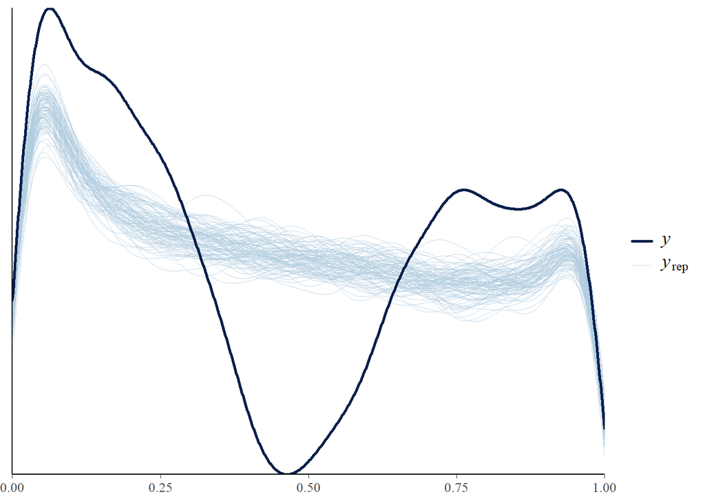

```r
pp_check(mdl_zoib3, ndraws = 100)
```

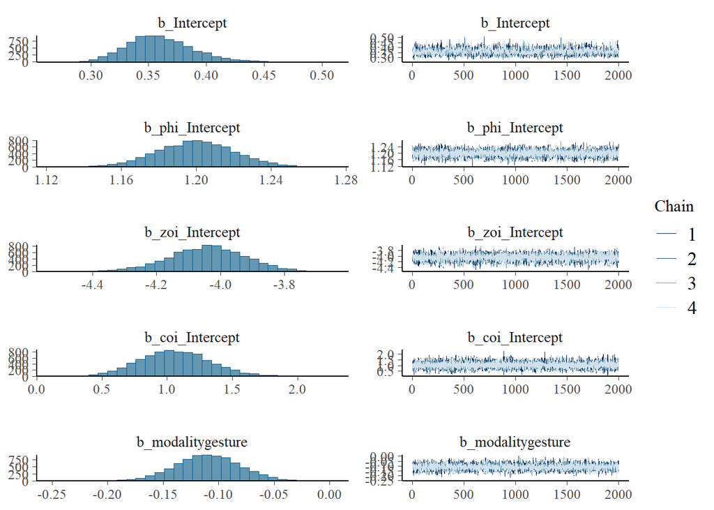

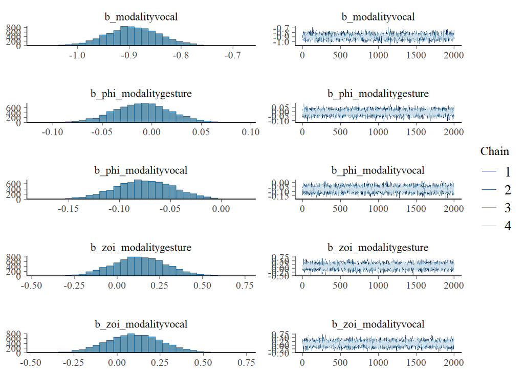

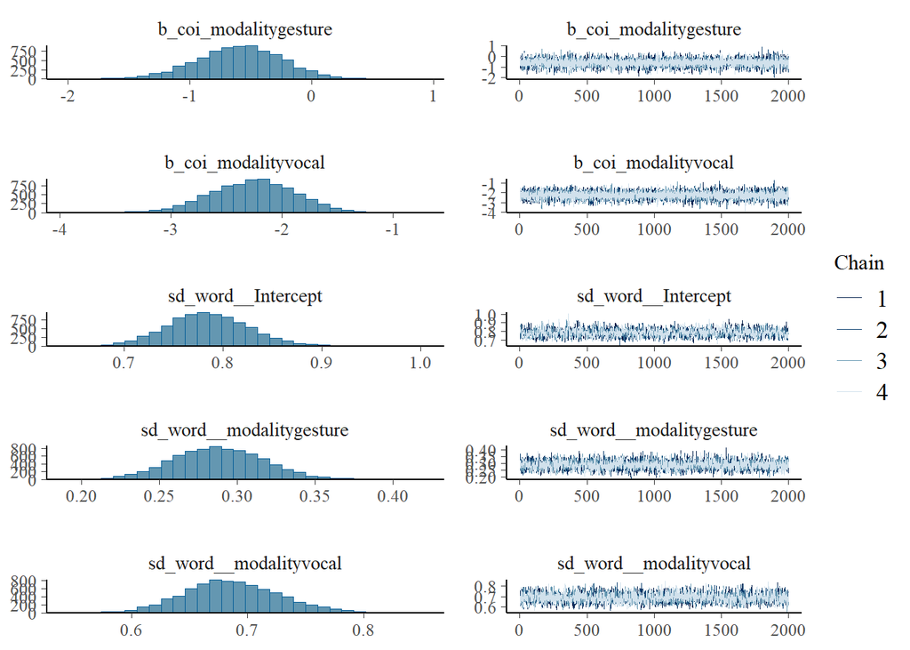

```r
plot(mdl_zoib3)
```

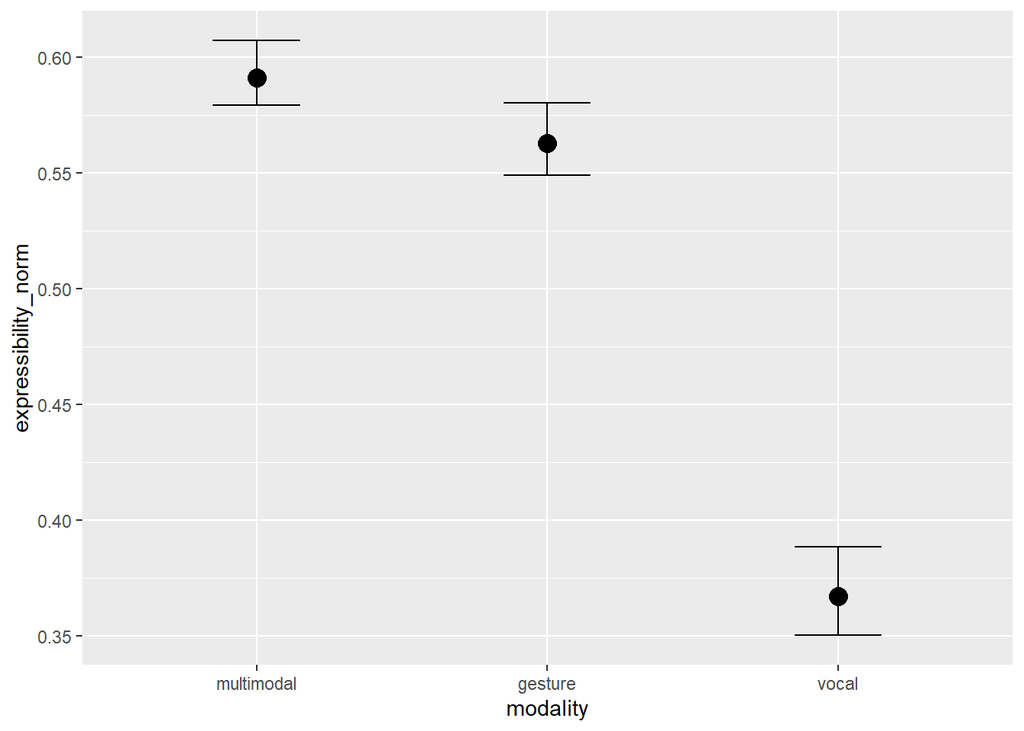

```r
conditional_effects(mdl_zoib3)
```

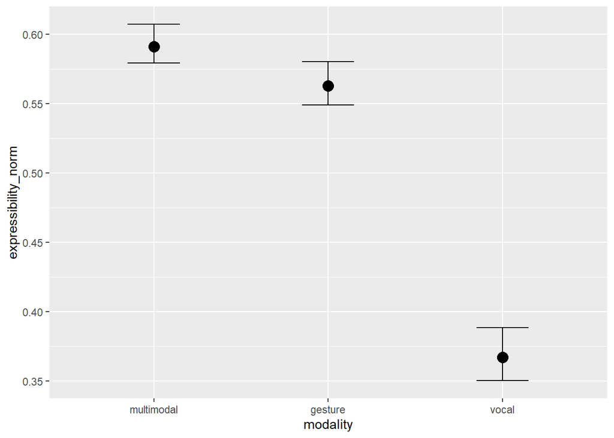

```r
conditional_effects(mdl_zoib3, sample_prior = "only")
```

Computer mdl3 loo.

```r
# run loo mdl3
if (file.exists(paste0(models, "mdl_zoib3_loo.rds"))) {
  mdl_zoib3_loo <- readRDS(paste0(models, "mdl_zoib3_loo.rds"))
} else {
  mdl_zoib3_loo <- loo(mdl_zoib3)
  saveRDS(mdl_zoib3_loo, paste0(models, "mdl_zoib3_loo.rds"))
}
```

And for the final, we take simple phi, zoi, and coi, but make the predictors more complex.

```r
# compute mdl4
mdl_zoib4 <- brm(bf(expressibility_norm ~ 1 + modality + PoS + SemanticCat +
                      (1 + modality || word),
                   phi ~ modality,
                   zoi ~ modality,
                   coi ~ modality),
                data = data,
                prior = priors_beta_narrow,
                family = zero_one_inflated_beta(),
                backend = "cmdstanr",
                cores = 4,
                chains = 4,
                init = 0,
                iter = 4000,
                warmup = 2000,
                seed = 42,
                control = list(max_treedepth = 13,
                               adapt_delta = 0.99),
                file = paste0(models, "mdl_zoib4.rds"))

# compress the model more
saveRDS(mdl_zoib4, file = paste0(models, "mdl_zoib4.rds"), compress = "xz")
```

Check mdl4.

```r
mdl_zoib4 <- readRDS(paste0(models, "mdl_zoib4.rds"))

summary(mdl_zoib4)
```

```
##  Family: zero_one_inflated_beta
##   Links: mu = logit; phi = log; zoi = logit; coi = logit
## Formula: expressibility_norm ~ 1 + modality + PoS + SemanticCat + (1 + modality || word)
##          phi ~ modality
##          zoi ~ modality
##          coi ~ modality
##    Data: data (Number of observations: 12678)
##   Draws: 4 chains, each with iter = 4000; warmup = 2000; thin = 1;
##          total post-warmup draws = 8000
##
## Multilevel Hyperparameters:
## ~word (Number of levels: 206)
##                     Estimate Est.Error l-95% CI u-95% CI Rhat Bulk_ESS Tail_ESS
## sd(Intercept)           0.73      0.04     0.65     0.81 1.00     1882     4274
## sd(modalitygesture)     0.29      0.03     0.23     0.35 1.00     3455     5260
## sd(modalityvocal)       0.69      0.04     0.61     0.77 1.00     3061     4614
##
## Regression Coefficients:
##                        Estimate Est.Error l-95% CI u-95% CI Rhat Bulk_ESS
## Intercept                  0.43      0.10     0.23     0.62 1.00     4015
## phi_Intercept              1.20      0.02     1.16     1.24 1.00    12110
## zoi_Intercept             -4.04      0.12    -4.28    -3.81 1.00    12840
## coi_Intercept              1.06      0.27     0.56     1.60 1.00    12077
## modalitygesture           -0.11      0.03    -0.17    -0.05 1.00     7551
## modalityvocal             -0.89      0.05    -0.98    -0.79 1.00     2083
## PoSadjective              -0.12      0.12    -0.36     0.11 1.00     2612
## PoSadverb                 -0.11      0.16    -0.43     0.21 1.00     4888
## PoSdeterminer             -0.03      0.19    -0.42     0.35 1.00    13091
## PoSnoun                   -0.14      0.12    -0.38     0.09 1.00     2780
## PoSpronoun                -0.27      0.17    -0.60     0.06 1.00     4989
## PoSquestion               -0.07      0.19    -0.43     0.30 1.00    12110
## SemanticCataction          0.28      0.13     0.02     0.54 1.00     2542
## SemanticCatanimal          0.23      0.16    -0.08     0.55 1.00     3340
## SemanticCatbody           -0.05      0.14    -0.32     0.21 1.00     2621
## SemanticCatcognitive      -0.06      0.18    -0.41     0.30 1.00     8091
## SemanticCatemotion         0.27      0.17    -0.08     0.61 1.00     4638
## SemanticCatenvironment    -0.04      0.15    -0.33     0.26 1.00     2630
## SemanticCatlocomotion     -0.04      0.20    -0.42     0.34 1.00    11887
## SemanticCatmotion          0.09      0.19    -0.28     0.47 1.00     9617
## SemanticCatplant          -0.14      0.18    -0.50     0.21 1.00     6513
```

[output cut: 41 more lines]

```
## SemanticCatsocial          5183
## SemanticCatspatial         5427
## SemanticCattemperature     6253
## SemanticCatthing           4093
## SemanticCattime            5790
## phi_modalitygesture        6687
## phi_modalityvocal          6448
## zoi_modalitygesture        6611
## zoi_modalityvocal          6657
## coi_modalitygesture        6633
## coi_modalityvocal          6807
##
## Draws were sampled using sample(hmc). For each parameter, Bulk_ESS
## and Tail_ESS are effective sample size measures, and Rhat is the potential
## scale reduction factor on split chains (at convergence, Rhat = 1).
```

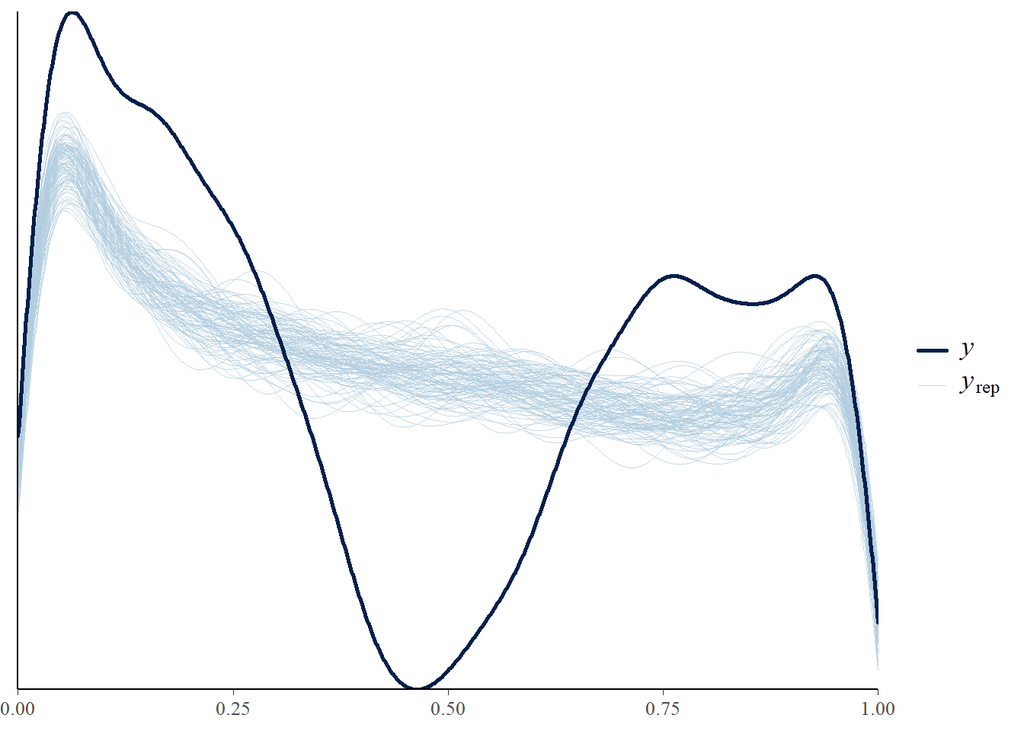

```r
pp_check(mdl_zoib4, ndraws = 100)
```

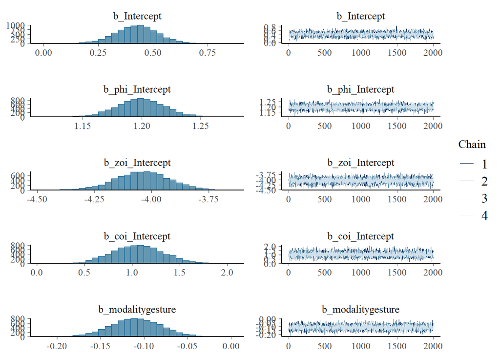

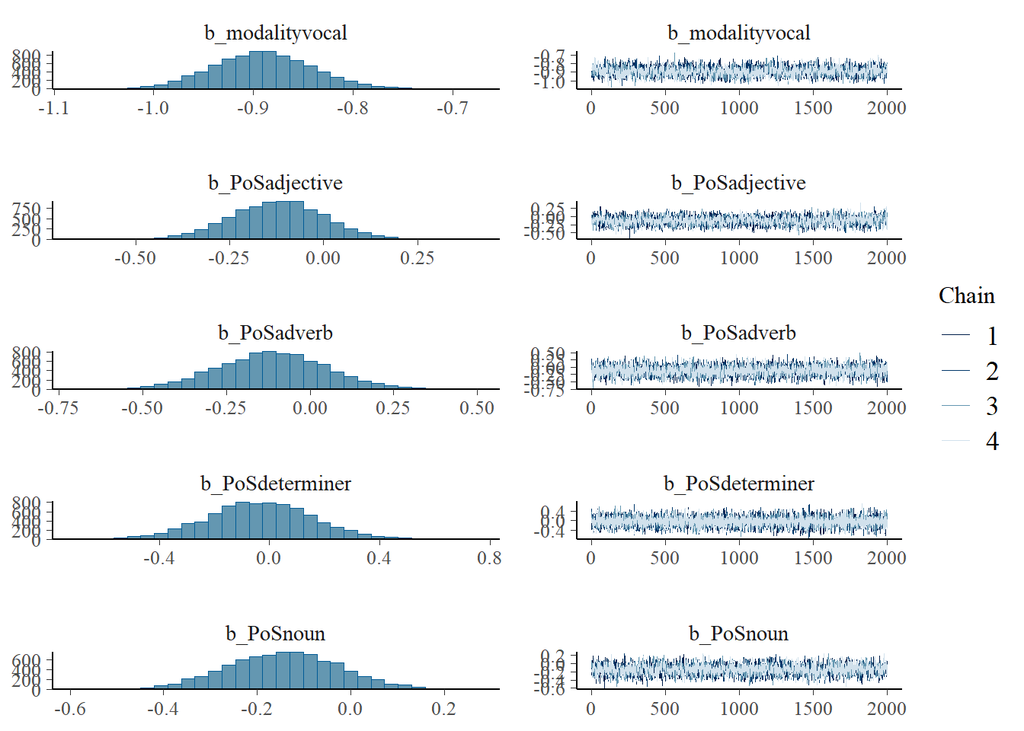

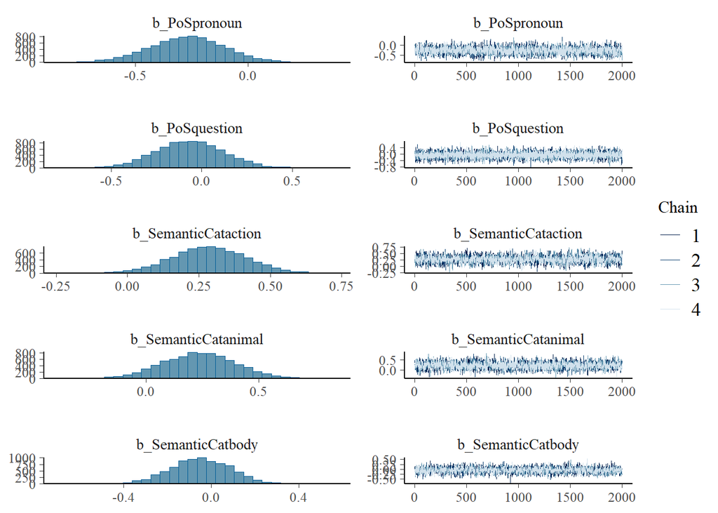

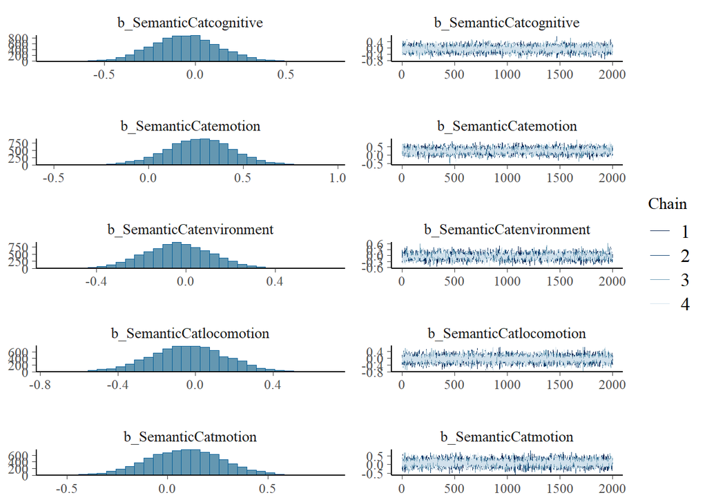

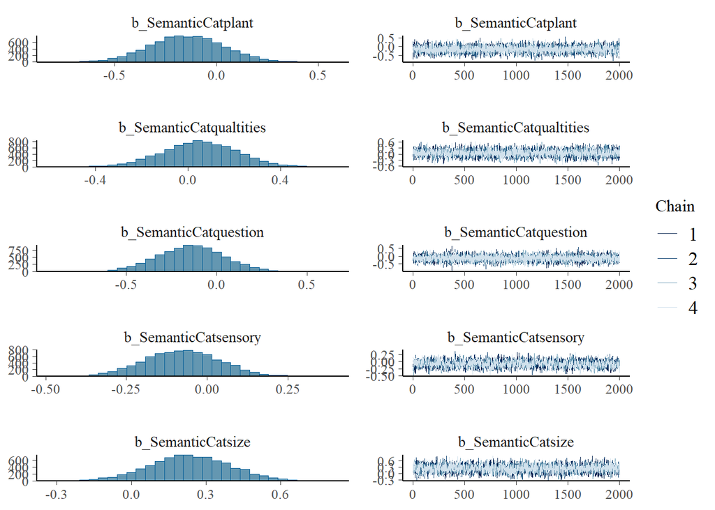

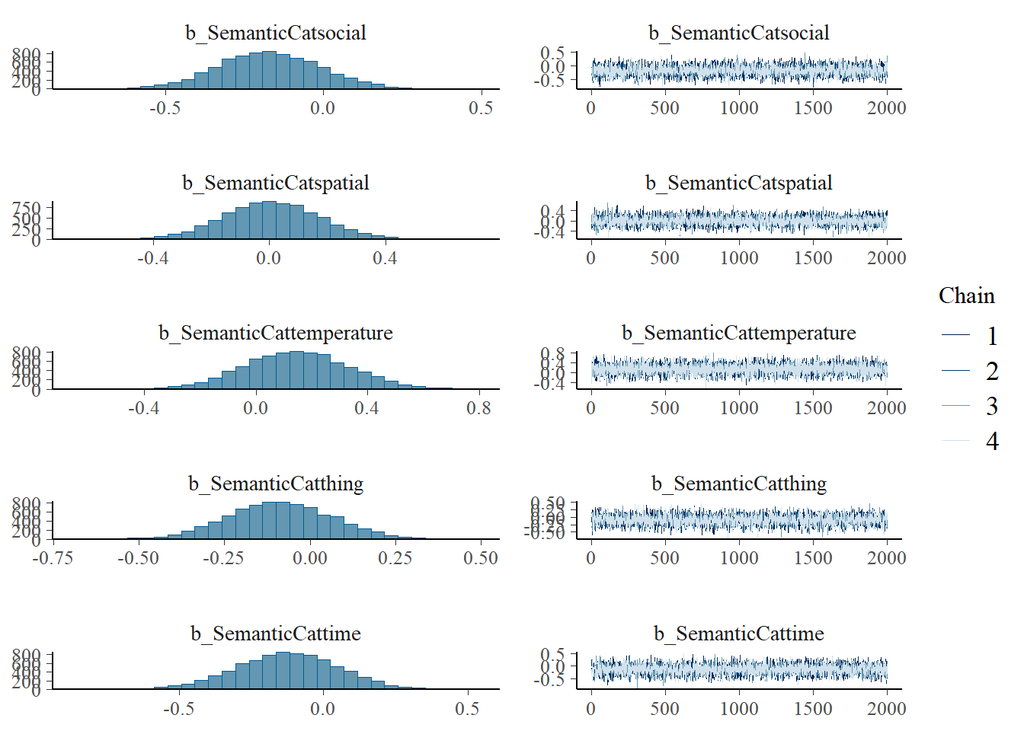

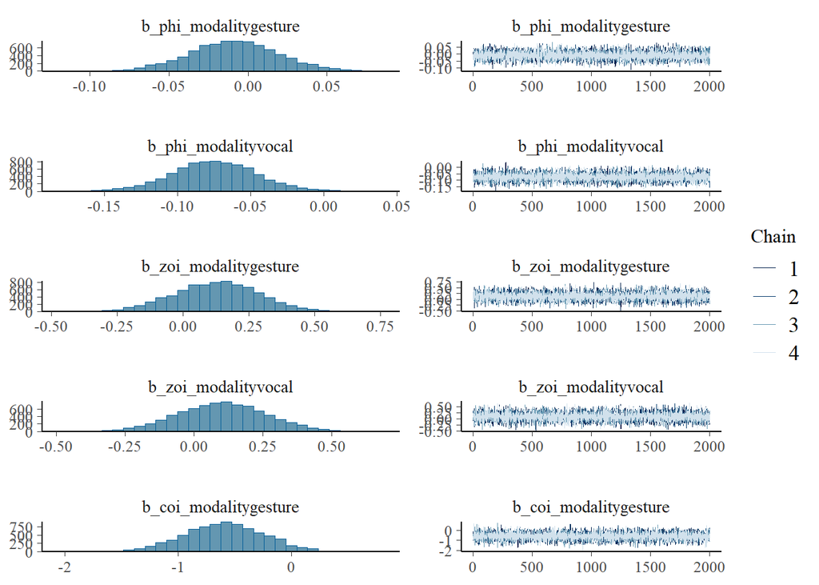

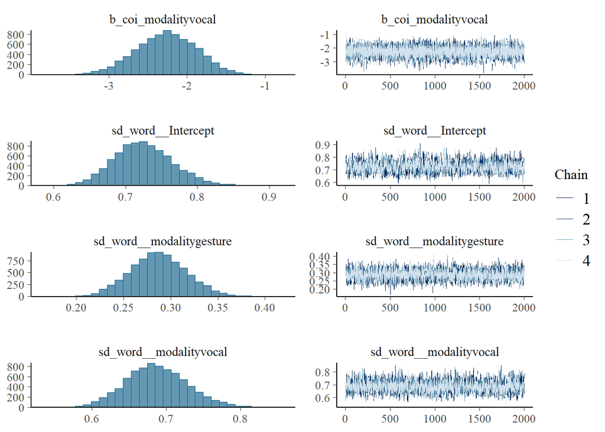

```r
plot(mdl_zoib4)
```